# Chapter 3

## Describing Relationships

- In the last chapter we described the shape of, say, the temperature readings in the airquality dataset.
- In this chapter, we will be exploring whether there is a relationship between temperature and the month in which the temperature was taken (spoiler alert: there is!).

### Multivariate data

##### There are three broad classes of bivariate (or two variable) relationships:

- The relationship between one categorical variable and one continuous variable
- The relationship between two categorical variables
- The relationship between two continuous variables

```r
head(iris)
```

|  | Sepal.Length | Sepal.Width | Petal.Length | Petal.Width | Species |
| --- | --- | --- | --- | --- | --- |
| 1 | 5.1 | 3.5 | 1.4 | 0.2 | setosa |
| 2 | 4.9 | 3.0 | 1.4 | 0.2 | setosa |
| 3 | 4.7 | 3.2 | 1.3 | 0.2 | setosa |
| 4 | 4.6 | 3.1 | 1.5 | 0.2 | setosa |
| 5 | 5.0 | 3.6 | 1.4 | 0.2 | setosa |
| 6 | 5.4 | 3.9 | 1.7 | 0.4 | setosa |

```r
mean(iris$Petal.Length[iris$Species==\versicolor\])
```

```
[1] 4.26
```

```r
mean(iris$Petal.Length[iris$Species==\virginica\])
```

```
[1] 5.55
```

There’s a far easier way to do this:

```r
by(iris$Petal.Length, iris$Species, mean)
```

```
iris$Species: setosa
[1] 1.46
------------------------------------------------------------
iris$Species: versicolor
[1] 4.26
------------------------------------------------------------
iris$Species: virginica
[1] 5.55
```

If we had reason to believe that the virginicas have a more widely varying petal length than the other two species, we could pass the sd function to the by function as follows:

```r
by(iris$Petal.Length, iris$Species, sd)
```

```
iris$Species: setosa
[1] 0.174
------------------------------------------------------------
iris$Species: versicolor
[1] 0.47
------------------------------------------------------------
iris$Species: virginica
[1] 0.552
```

```r
summary(iris)
```

```
  Sepal.Length   Sepal.Width    Petal.Length   Petal.Width        Species
 Min.   :4.30   Min.   :2.00   Min.   :1.00   Min.   :0.1   setosa    :50
 1st Qu.:5.10   1st Qu.:2.80   1st Qu.:1.60   1st Qu.:0.3   versicolor:50
 Median :5.80   Median :3.00   Median :4.35   Median :1.3   virginica :50
 Mean   :5.84   Mean   :3.06   Mean   :3.76   Mean   :1.2
 3rd Qu.:6.40   3rd Qu.:3.30   3rd Qu.:5.10   3rd Qu.:1.8
 Max.   :7.90   Max.   :4.40   Max.   :6.90   Max.   :2.5
```

```r
by(iris$Petal.Length, iris$Species, summary)
```

```
iris$Species: setosa
   Min. 1st Qu.  Median    Mean 3rd Qu.    Max.
   1.00    1.40    1.50    1.46    1.57    1.90
------------------------------------------------------------
iris$Species: versicolor
   Min. 1st Qu.  Median    Mean 3rd Qu.    Max.
   3.00    4.00    4.35    4.26    4.60    5.10
------------------------------------------------------------
iris$Species: virginica
   Min. 1st Qu.  Median    Mean 3rd Qu.    Max.
   4.50    5.10    5.55    5.55    5.88    6.90
```

Is a relationship between the average temperature across months?

```r
by(airquality$Temp, airquality$Month, mean)
```

```
airquality$Month: 5
[1] 65.5
------------------------------------------------------------
airquality$Month: 6
[1] 79.1
------------------------------------------------------------
airquality$Month: 7
[1] 83.9
------------------------------------------------------------
airquality$Month: 8
[1] 84
------------------------------------------------------------
airquality$Month: 9
[1] 76.9
```

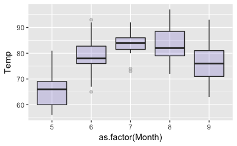

[figure not shown]

```r
library(ggplot2)
ggplot(airquality, aes(x=as.factor(Month), y=Temp)) +
  geom_boxplot(fill='slateblue', alpha=0.2)
```

### Relationship between two categorical variables

```r
ucba <- data.frame(UCBAdmissions)
head(ucba)
```

|  | Admit | Gender | Dept | Freq |
| --- | --- | --- | --- | --- |
| 1 | Admitted | Male | A | 512 |
| 2 | Rejected | Male | A | 313 |
| 3 | Admitted | Female | A | 89 |
| 4 | Rejected | Female | A | 19 |
| 5 | Admitted | Male | B | 353 |
| 6 | Rejected | Male | B | 207 |

```r
cross <- xtabs(Freq ~ Gender+Admit, data=ucba)
cross
```

```
        Admit
Gender   Admitted Rejected
  Male       1198     1493
  Female      557     1278
```

Is there a gender bias in UCB’s graduate admissions process? Perhaps, but it’s hard to tell from just looking at the 2x2 contingency table.

#### The values in each cell divided by the sum of the 4 cells:

```r
prop.table(cross)
```

```
        Admit
Gender   Admitted Rejected
  Male      0.265    0.330
  Female    0.123    0.282
```

#### The value of each cell divided by the sum of the row cells:

```r
prop.table(cross, 1)
```

```
        Admit
Gender   Admitted Rejected
  Male      0.445    0.555
  Female    0.304    0.696
```

#### The value of each cell divided by the sum of the column cells:

```r
prop.table(cross, 2)
```

```
        Admit
Gender   Admitted Rejected
  Male      0.683    0.539
  Female    0.317    0.461
```

To aid us in either implicating UCB of a sexist admissions machine or exonerating them, it would help to look at a proportions table. Using a proportions table, we can easily compare the proportion of the total number of males who were accepted versus the proportion of the total number of females who were accepted. If the proportions are more or less equal, we can conclude that gender does not constitute a factor in UCB’s admissions process. If this is the case, gender and admission status is said to be conditionally independent.

```r
cross2 <- xtabs(Freq ~ Gender + Admit, data=ucba[ucba$Dept=="A",])
prop.table(cross2, 1)
```

[output not shown]

Checking a different dept, “Dept A”, there appears to be a bias towards women. If there were any bias in admissions, these data didn’t prove it.

** This is probably the most famous case of Simpson’s Paradox, and it is also why this dataset is built into R. The lesson here is to be careful when using pooled data, and look out for hidden variables. **

### The relationship between two continuous variables

```r
head(women)
```

|  | height | weight |
| --- | --- | --- |
| 1 | 58 | 115 |
| 2 | 59 | 117 |
| 3 | 60 | 120 |
| 4 | 61 | 123 |
| 5 | 62 | 126 |
| 6 | 63 | 129 |

This dataset has a positive relationship.

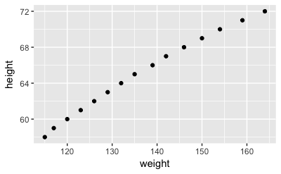

```r
library(ggplot2)
ggplot(women, aes(x=weight, y=height)) +
  geom_point()
```

### Covariance

```
[1] 69
```

### Correlation coefficients

A Pearson correlation coefficient of 1 will denote a perfectly positive (linear) relationship, a r of -1 will denote a perfectly negative (linear) relationship, and a r of 0 will denote no (linear) relationship.

```
[1] 0.9954948
```

```
[1] 0.9954948
```

### Rank

```
[1] 6 4 5 3 2 1 7
```

```
[1] 6 4 5 3 2 1 7
```

```
[1] 1
```

```
[1] 0.917552
```

[output not shown]

```
             Sepal.Length Sepal.Width Petal.Length Petal.Width
Sepal.Length    1.0000000  -0.1175698    0.8717538   0.8179411
Sepal.Width    -0.1175698   1.0000000   -0.4284401  -0.3661259
Petal.Length    0.8717538  -0.4284401    1.0000000   0.9628654
Petal.Width     0.8179411  -0.3661259    0.9628654   1.0000000
```

```
             Sepal.Length Sepal.Width Petal.Length Petal.Width
Sepal.Length    1.0000000  -0.1667777    0.8818981   0.8342888
Sepal.Width    -0.1667777   1.0000000   -0.3096351  -0.2890317
Petal.Length    0.8818981  -0.3096351    1.0000000   0.9376668
Petal.Width     0.8342888  -0.2890317    0.9376668   1.0000000
```

### Categorical Continuous Variables

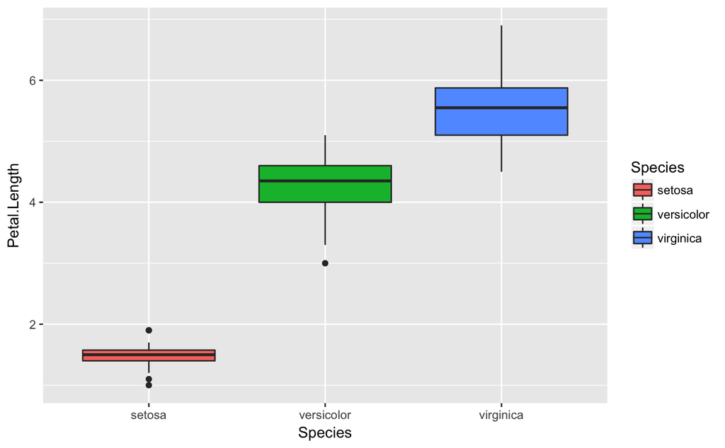

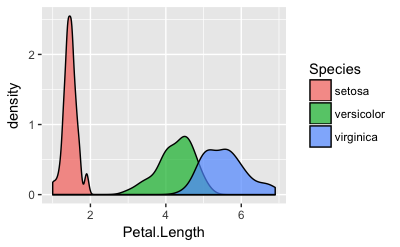

```r
qplot(Petal.Length, data=iris, geom="density", alpha=I(.7), fill=Species)
```

```r
# install.packages("vcd")
library(vcd)
ucba <- data.frame(UCBAdmissions)
```

[figure not shown]

```r
mosaic(Freq ~ Gender + Admit, data=ucba, shade=TRUE, legend=TRUE)
```

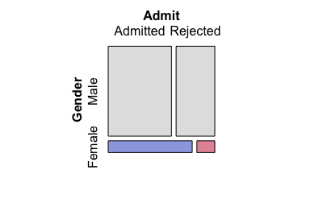

```r
mosaic(Freq ~ Gender+Admit, data=ucba[ucba$Dept=="A",], shade=TRUE, legend=FALSE)
```

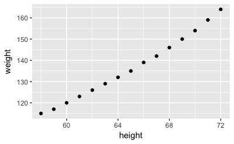

```r
qplot(height, weight, data=women, geom="point")
```

[output not shown]

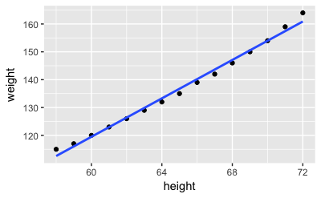

```r
qplot(height, weight, data=women, geom=c("point", "smooth"), method="lm", se=FALSE)
```

[output not shown]

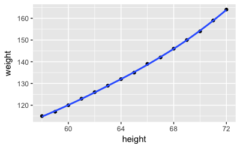

```r
qplot(height, weight, data=women, geom=c("point", "smooth"), se=FALSE)
```

[output not shown]

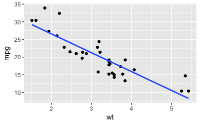

```r
qplot(wt, mpg, data=mtcars, geom=c("point", "smooth"), method='lm', se=FALSE)
```

[output not shown]

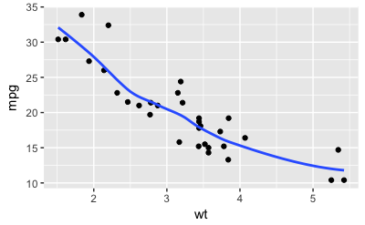

```r
qplot(wt, mpg, data=mtcars, geom=c("point", "smooth"), se=FALSE)
```

```r
install.packages('corrgram')
```